# Análisis sensorial de 4 estilos de vinos espumantes de Argentina

Modelos Lineales en R

Aníbal Catania

# Introducción

Los vinos espumantes representan una pequeña pero significativa proporción de los vinos de la industria Argentina con una producción anual de 42500000 de litros. Existe una considerable diversidad entre los diferentes estilos, desde vinos espumantes muy frutados hasta aquellos que muestran una gran complejidad debido a la autólisis de levaduras y a la crianza. Actualmente no se ha publicaod ningún trabajo en el cual se realize un análisis sensorial de los vinos espumantes de Argentina.  
En este trabajo, la hipótesises que Los panelistas van a poder diferenciar los vinos por el descriptor dulce.

# Objetivo

- El presente estudio busca caracterizar sensorialmente los distintos estilos de los vinos espumantes argentinos.

# Descripcición de los datos empleados

Análisis sensorial de 4 vinos espumantes

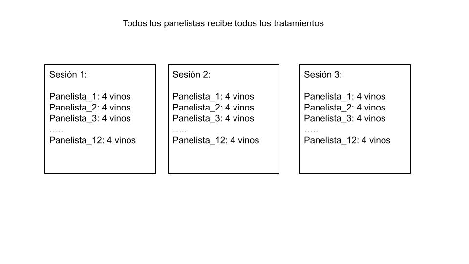

#### Hipótesis: Los panelistas pudieron diferenciar los vinos por el descriptor dulce

#### Diseño: DCA

#### UE: panelista (n=12)

#### VR: descriptor: dulce

#### Factores:

#### vinos (fijo) ( 4 niveles)

#### Panelista (aleatorio) (12 niveles)

#### sesión (aleatorio) ( 3 niveles) repeticiones

```r
kable(data[1:50, c(1,2,3,20,21,22,23,24,25,26)], format = "latex") %>%
 kable_styling(font_size = 8)
```

# Descripción de la metodología

```r
kable(table(data$panelista, data$vino),format = "latex")
```

# Resultados

## Estadśitica Descriptiva

```r
data %>%
  group_by(vino) %>%
 select(dulce) %>%
  summarise_all(.funs = c(
    n = length,
    ybar = mean,
    sd = sd,
    min = min,
    max = max
    ))
```

```
## # A tibble: 4 x 6
##   vino       n  ybar    sd   min   max
##   <chr>  <int> <dbl> <dbl> <dbl> <dbl>
## 1 vino_1    36  5.19  2.59   0    12.1
## 2 Vino_2    36  5.43  3.06   0.1  13.4
## 3 Vino_3    36  8.79  2.98   3.2  14.1
## 4 Vino_4    36  4.82  3.00   0.3  13.3
```

```r
summarize(data)
```

```
## # A tibble: 1 x 0
```

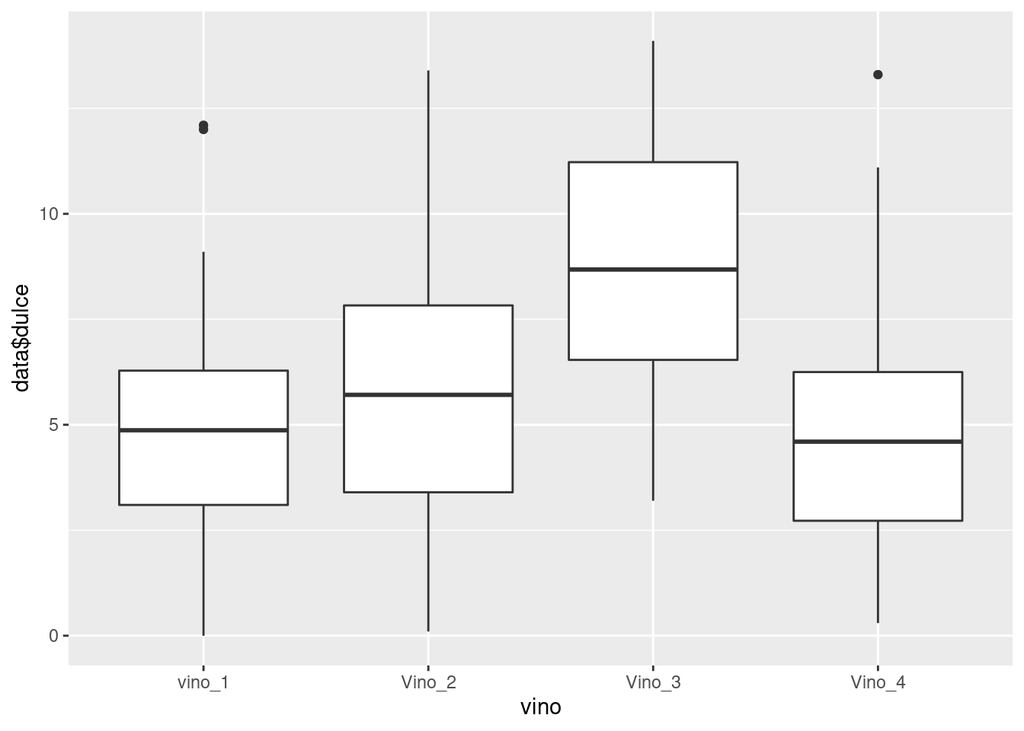

```r
plot <-ggplot(data, aes(vino,data$dulce))+
  geom_boxplot()
plot
```

## Modelo

```r
library(lmerTest)
m1<- lmer(dulce~vino
                  + (1 | panelista)
                  + (1 | sesion)
                  + (1 | panelista:sesion)
                  + (1 | panelista:vino)
                  + (1 | sesion:vino), data=data)

anova(m1)
```

```
## Type III Analysis of Variance Table with Satterthwaite's method
##      Sum Sq Mean Sq NumDF  DenDF F value    Pr(>F)
## vino  348.9   116.3     3 32.994  33.487 3.991e-10 ***
## ---
## Signif. codes:  0 '***' 0.001 '**' 0.01 '*' 0.05 '.' 0.1 ' ' 1
```

## Supuestos

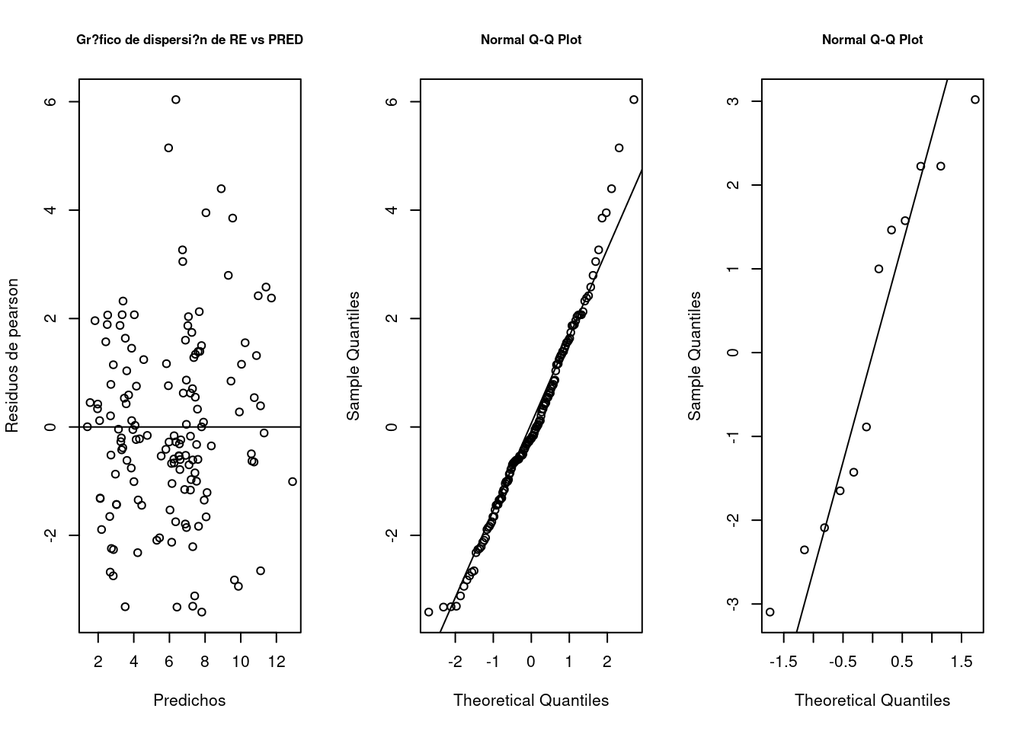

```r
e<-resid(m1)
pre<-predict(m1) #predichos
alfai<-ranef(m1)$panelista$'(Intercept)'

par(mfrow = c(1, 3))
plot(pre,e, xlab="Predichos", ylab="Residuos de pearson",main="Gr?fico de dispersi?n de RE vs PRED",cex.main=.8 )
abline(0,0)
qqnorm(e, cex.main=.8)
qqline(e)
qqnorm(alfai, cex.main=.8)
qqline(alfai)
```

```r
shapiro.test(e)
```

```
##
##  Shapiro-Wilk normality test
##
## data:  e
## W = 0.97801, p-value = 0.02035
```

```r
shapiro.test(alfai)
```

```
##
##  Shapiro-Wilk normality test
##
## data:  alfai
## W = 0.90889, p-value = 0.2064
```

```r
library(car)
 leveneTest(residuals(m1) ~ data$vino)
```

```
## Levene's Test for Homogeneity of Variance (center = median)
##        Df F value Pr(>F)
## group   3  0.4227  0.737
##       140
```

## Comparaciones

```r
library(emmeans)
library(multcomp)

lsd<-emmeans(m1,  pairwise~ vino)
lsd
```

```
## $emmeans
##  vino   emmean    SE   df lower.CL upper.CL
##  vino_1   5.19 0.758 14.4     3.57     6.81
##  Vino_2   5.43 0.758 14.4     3.81     7.06
##  Vino_3   8.79 0.758 14.4     7.16    10.41
##  Vino_4   4.82 0.758 14.4     3.20     6.44
##
## Degrees-of-freedom method: kenward-roger
## Confidence level used: 0.95
##
## $contrasts
##  contrast        estimate    SE   df t.ratio p.value
##  vino_1 - Vino_2   -0.242 0.449 5.07  -0.540  0.9454
##  vino_1 - Vino_3   -3.594 0.449 5.07  -8.008  0.0018
##  vino_1 - Vino_4    0.373 0.449 5.07   0.832  0.8381
##  Vino_2 - Vino_3   -3.352 0.449 5.07  -7.468  0.0025
##  Vino_2 - Vino_4    0.616 0.449 5.07   1.371  0.5633
##  Vino_3 - Vino_4    3.967 0.449 5.07   8.840  0.0011
##
## Degrees-of-freedom method: kenward-roger
## P value adjustment: tukey method for comparing a family of 4 estimates
```

```r
#cld(lsd, adjust="tuckey", Letters = LETTERS)
```

## Intervalos de confianza para la diferencia de medias

```r
confint(emmeans(m1, pairwise ~ vino))
```

```
## $emmeans
##  vino   emmean    SE   df lower.CL upper.CL
##  vino_1   5.19 0.758 14.4     3.57     6.81
##  Vino_2   5.43 0.758 14.4     3.81     7.06
##  Vino_3   8.79 0.758 14.4     7.16    10.41
##  Vino_4   4.82 0.758 14.4     3.20     6.44
##
## Degrees-of-freedom method: kenward-roger
## Confidence level used: 0.95
##
## $contrasts
##  contrast        estimate    SE   df lower.CL upper.CL
##  vino_1 - Vino_2   -0.242 0.449 5.07    -1.89     1.40
##  vino_1 - Vino_3   -3.594 0.449 5.07    -5.24    -1.95
##  vino_1 - Vino_4    0.373 0.449 5.07    -1.27     2.02
##  Vino_2 - Vino_3   -3.352 0.449 5.07    -5.00    -1.71
##  Vino_2 - Vino_4    0.616 0.449 5.07    -1.03     2.26
##  Vino_3 - Vino_4    3.967 0.449 5.07     2.32     5.61
##
## Degrees-of-freedom method: kenward-roger
## Confidence level used: 0.95
## Conf-level adjustment: tukey method for comparing a family of 4 estimates
```

## Gráfico Final

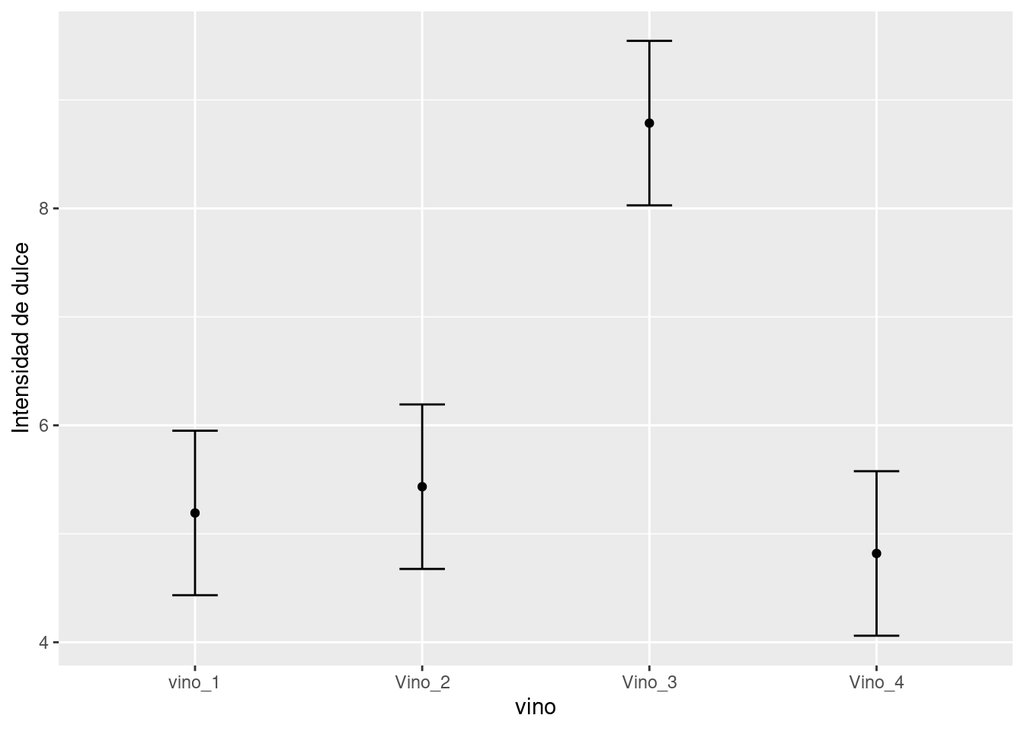

```r
comp1<-emmeans(m1, pairwise ~ vino)
resumen<-as.data.frame(comp1$emmeans)

ggplot(resumen, aes(x=vino, y=emmean)) +
  geom_point(position=position_dodge(), stat="identity", fill="blue") + labs(y="Intensidad de dulce") +
  geom_errorbar(aes(ymin=emmean-SE, ymax=emmean+SE),
                width=.2)
```

## Efectos aleatorios

```r
summary(m1)
```

```
## Linear mixed model fit by REML. t-tests use Satterthwaite's method [
## lmerModLmerTest]
## Formula:
## dulce ~ vino + (1 | panelista) + (1 | sesion) + (1 | panelista:sesion) +
##     (1 | panelista:vino) + (1 | sesion:vino)
##    Data: data
##
## REML criterion at convergence: 627.6
##
## Scaled residuals:
##     Min      1Q  Median      3Q     Max
## -1.8324 -0.5458 -0.1131  0.6169  3.2402
##
## Random effects:
##  Groups           Name        Variance Std.Dev.
##  panelista:vino   (Intercept) 0.0509   0.2256
##  panelista:sesion (Intercept) 0.2539   0.5039
##  sesion:vino      (Intercept) 0.0000   0.0000
##  panelista        (Intercept) 4.8749   2.2079
##  sesion           (Intercept) 0.1831   0.4280
##  Residual                     3.4729   1.8636
## Number of obs: 144, groups:
## panelista:vino, 48; panelista:sesion, 36; sesion:vino, 12; panelista, 12; sesion, 3
##
## Fixed effects:
##             Estimate Std. Error      df t value Pr(>|t|)
## (Intercept)   5.1919     0.7583 15.0658   6.847 5.41e-06 ***
## vinoVino_2    0.2424     0.4488 32.9941   0.540    0.593
## vinoVino_3    3.5942     0.4488 32.9941   8.008 3.07e-09 ***
## vinoVino_4   -0.3732     0.4488 32.9941  -0.831    0.412
## ---
## Signif. codes:  0 '***' 0.001 '**' 0.01 '*' 0.05 '.' 0.1 ' ' 1
##
## Correlation of Fixed Effects:
##            (Intr) vnVn_2 vnVn_3
## vinoVino_2 -0.296
## vinoVino_3 -0.296  0.500
## vinoVino_4 -0.296  0.500  0.500
## optimizer (nloptwrap) convergence code: 0 (OK)
## boundary (singular) fit: see ?isSingular
```